# SDS365 - HW2, Web Site

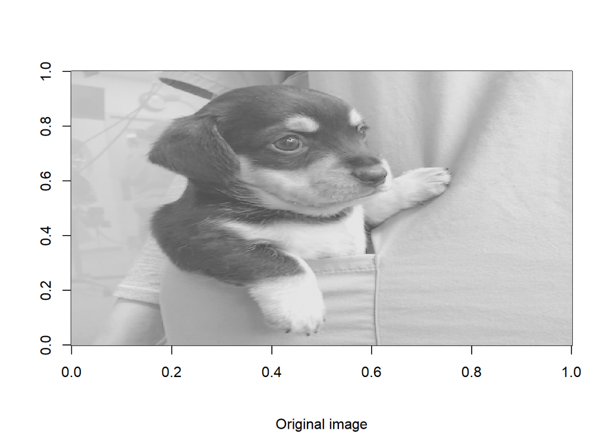

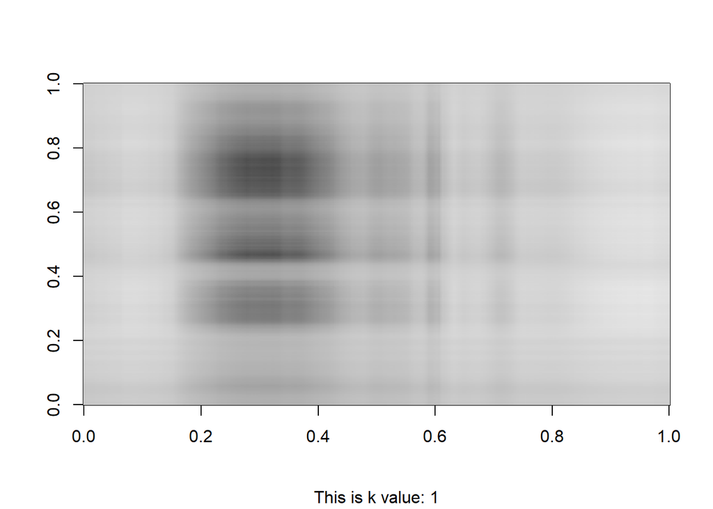

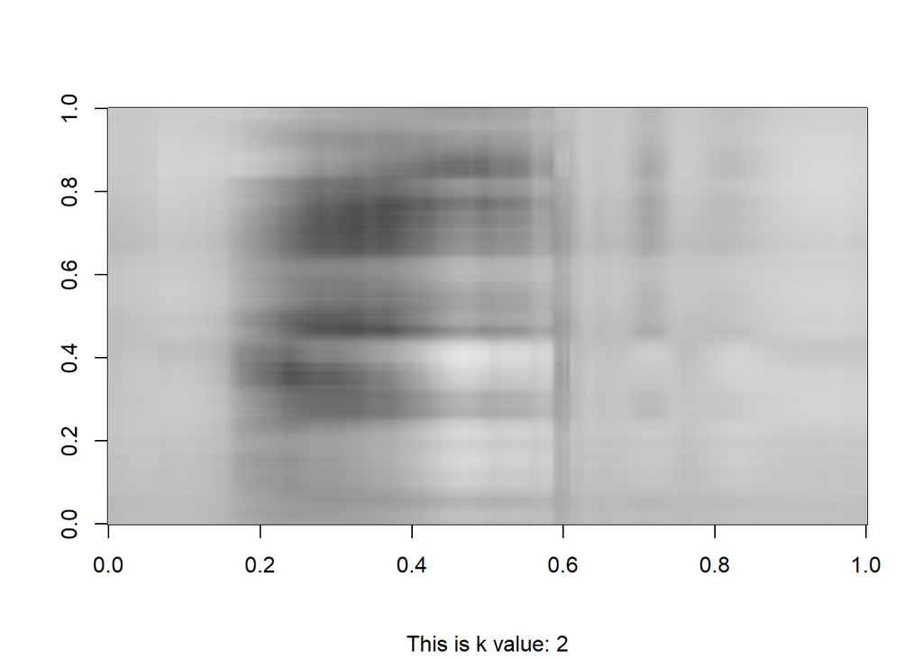

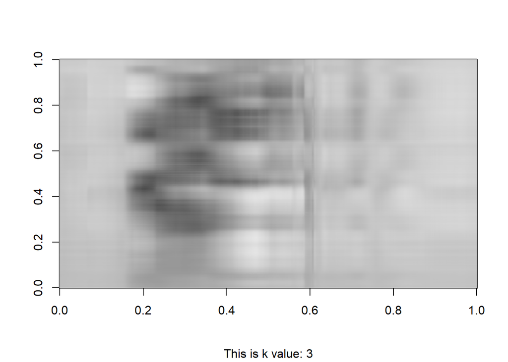

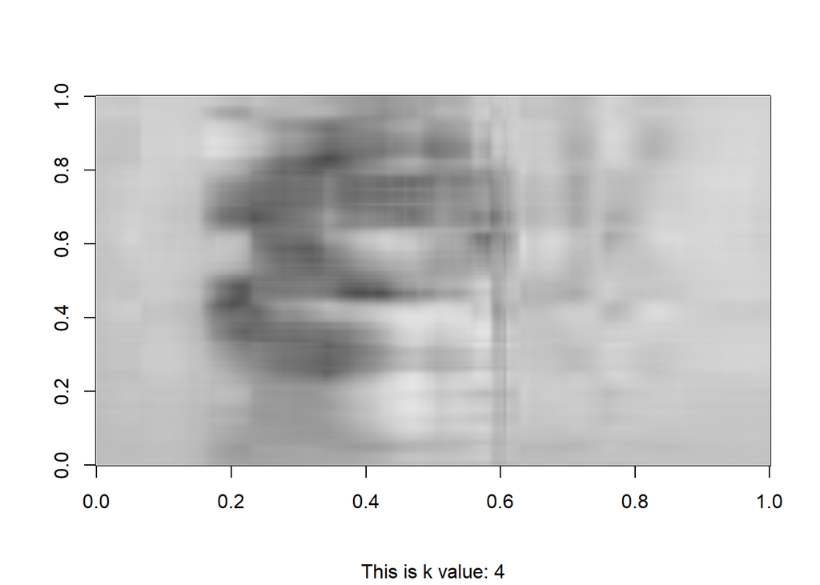

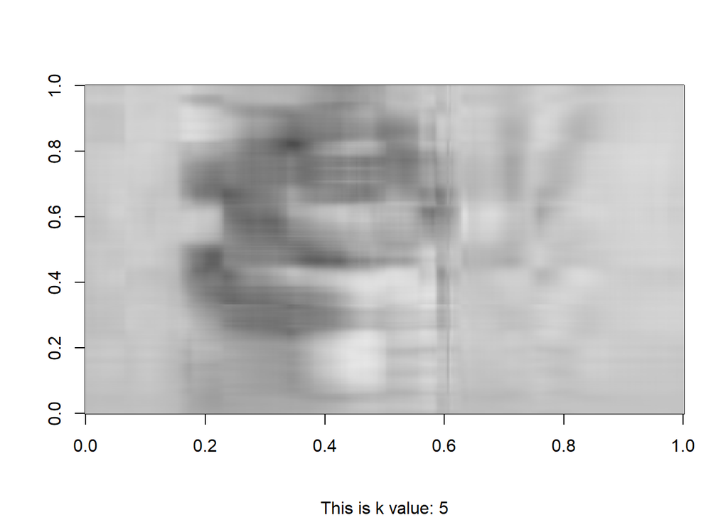

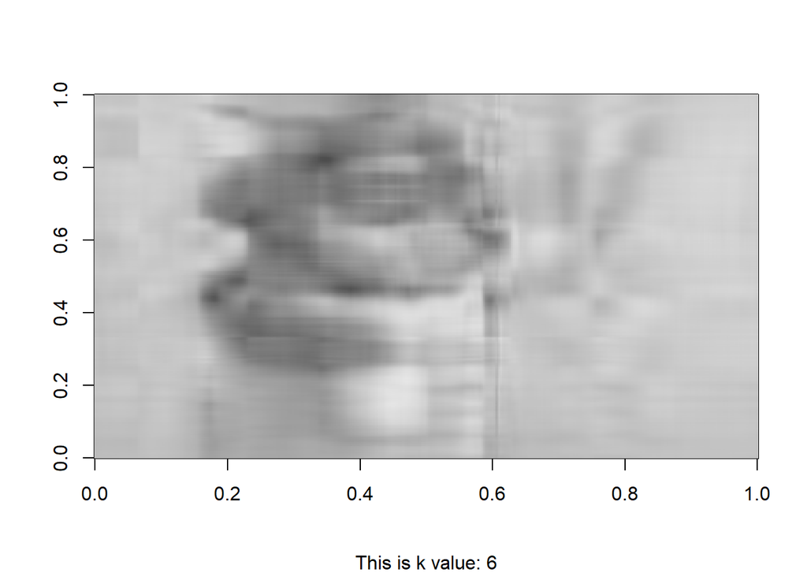

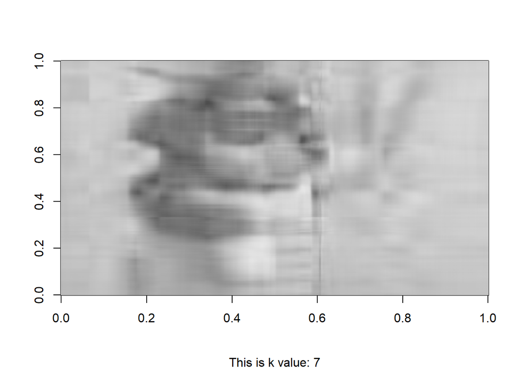

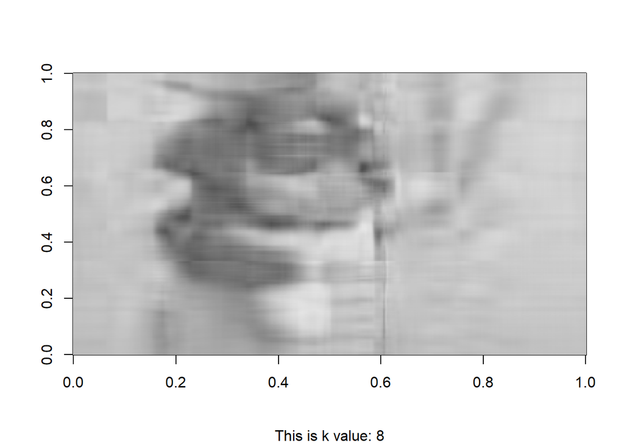

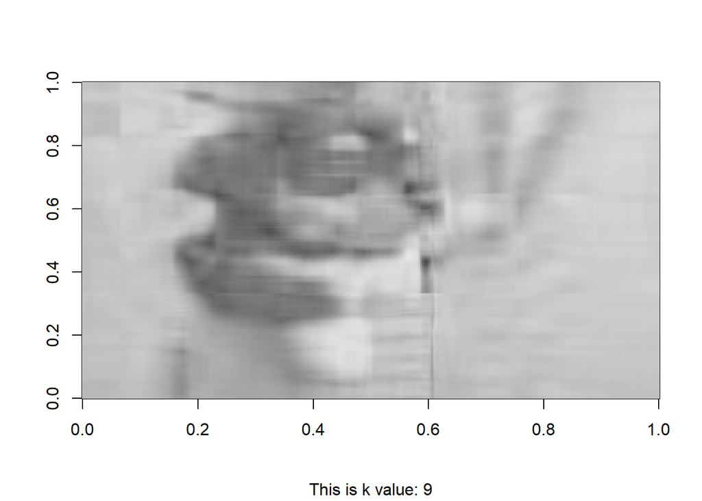

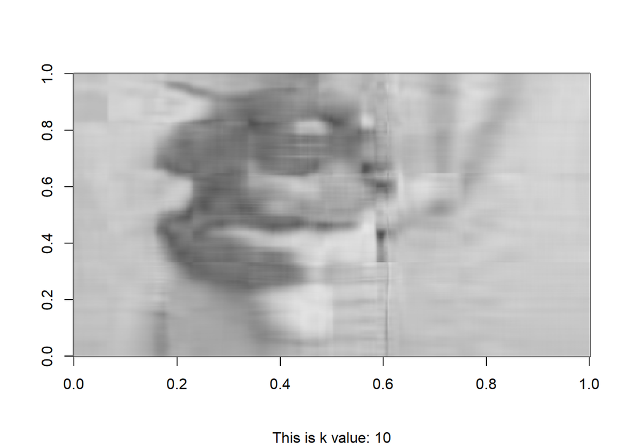

```r
first_10_img(img3, grayscale = TRUE)
```

2. A plot of the approximation error vs. 𝑘 for all possible values of 𝑘

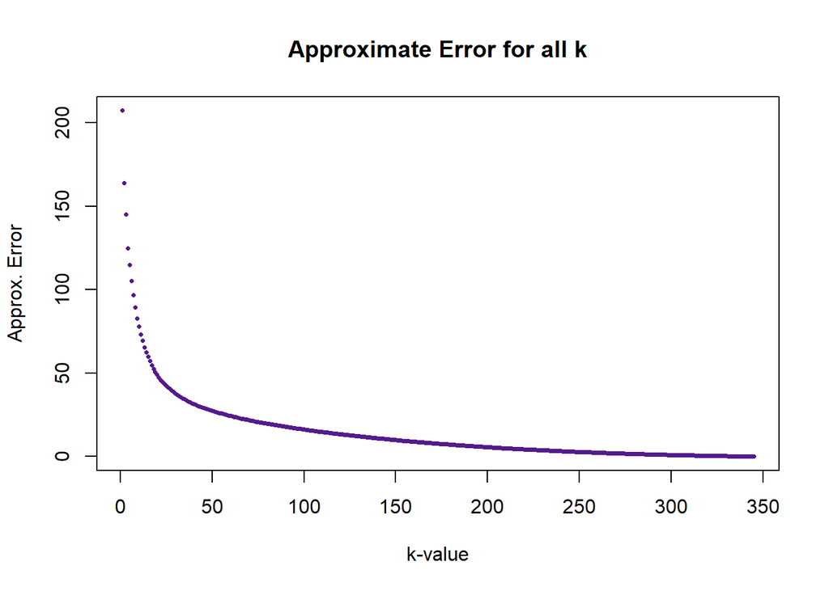

```r
k_error(img3)
```

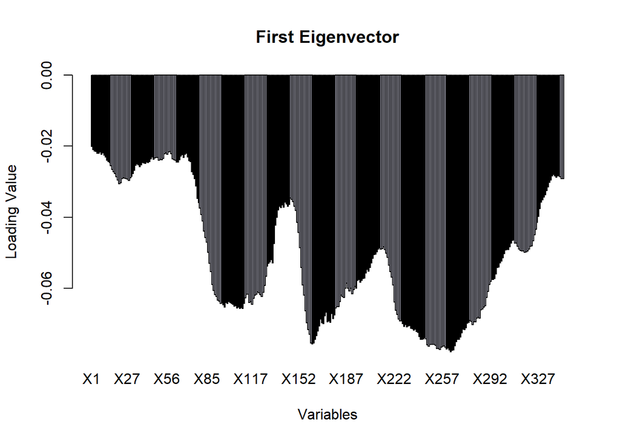

```r
# First eigenvector
eigenvector_plot(img3)
```

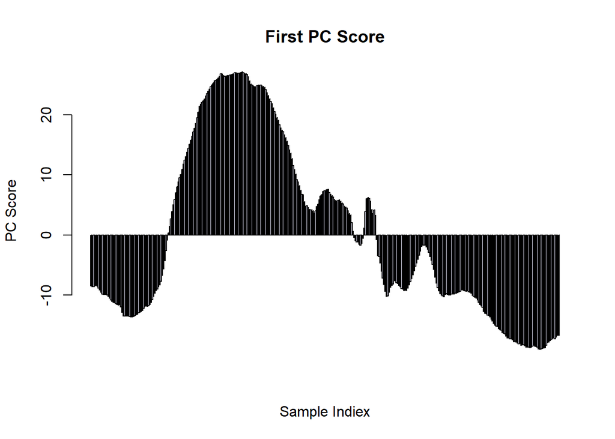

```r
# First PC score
pcscore_plot(img3)
```

4. Give your opinion for each image of at what value of 𝑘 you think the approximation to the image is sufficiently good.

This image is sufficiently clear at *k* = 10, as in a viewer can tell that it’s a dog if they squint.

**Image 4 Plots**

1. A plot of the original image followed by the first 10 PCA approximations (i.e. 𝑘 = 1, … , 10)

for that image;

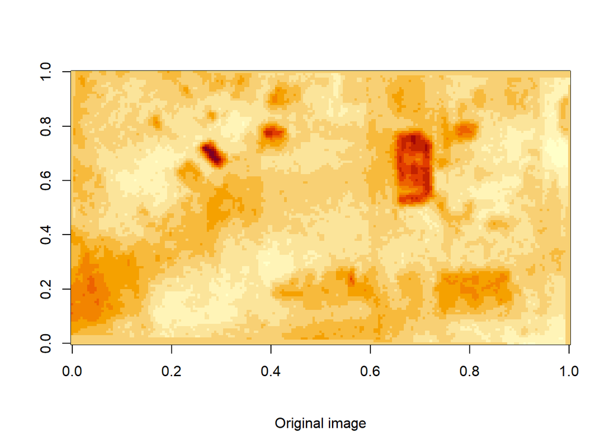

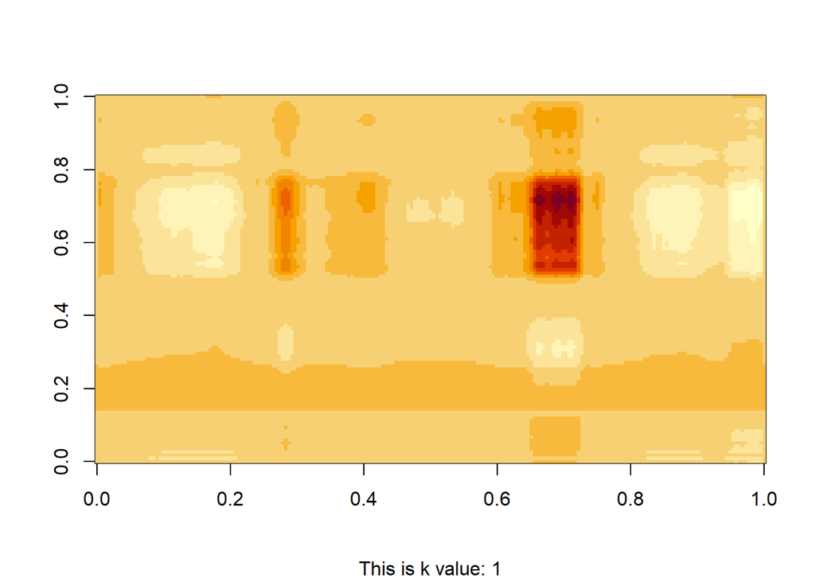

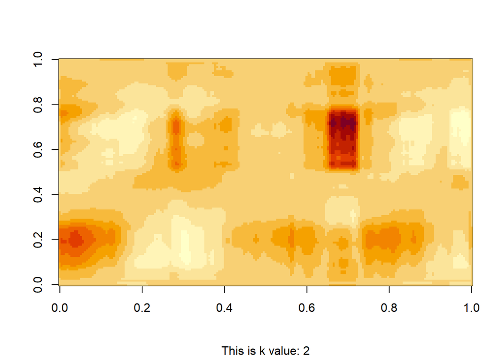

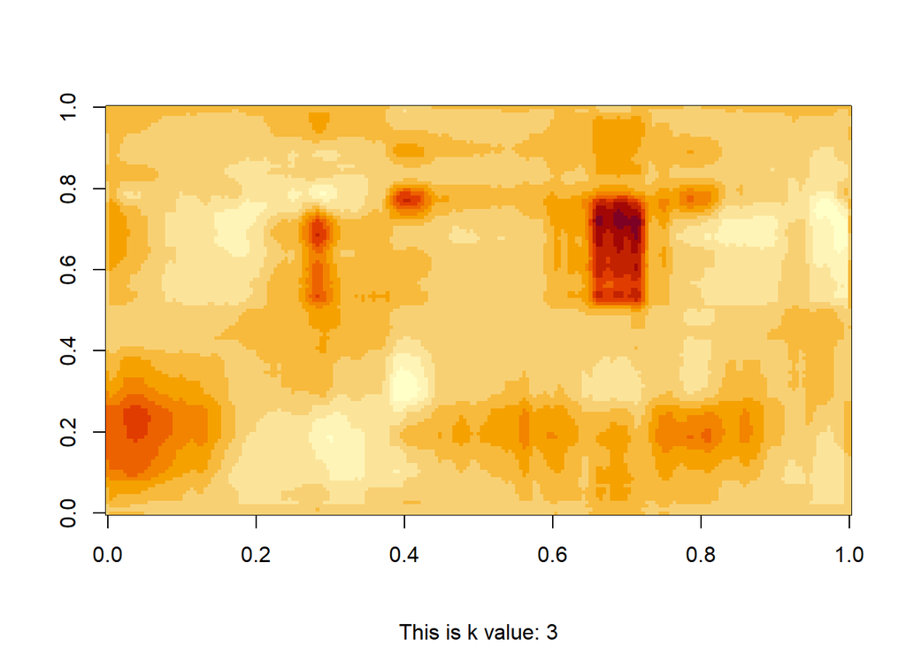

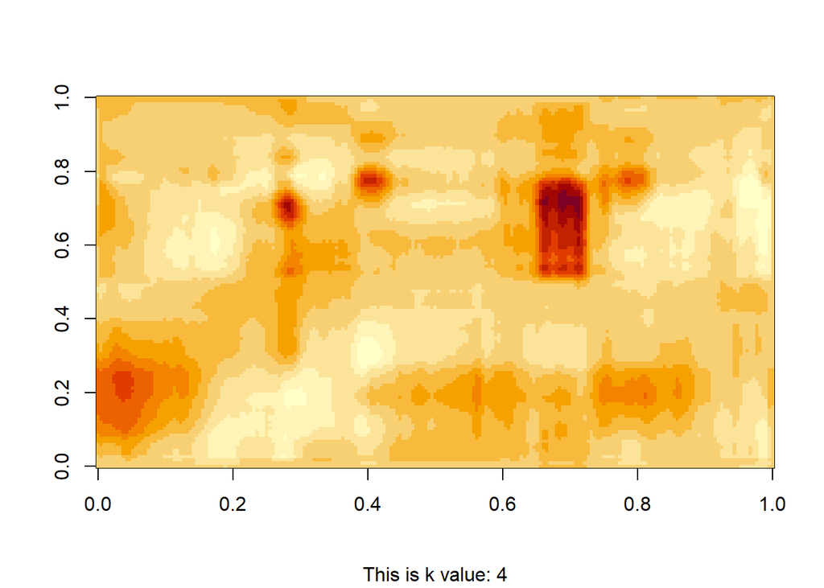

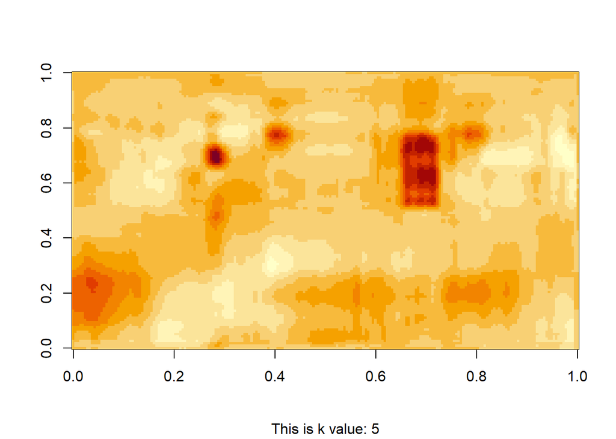

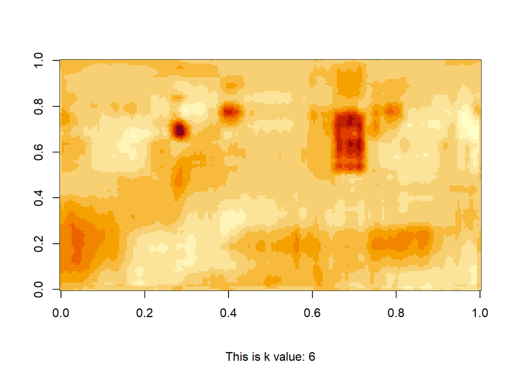

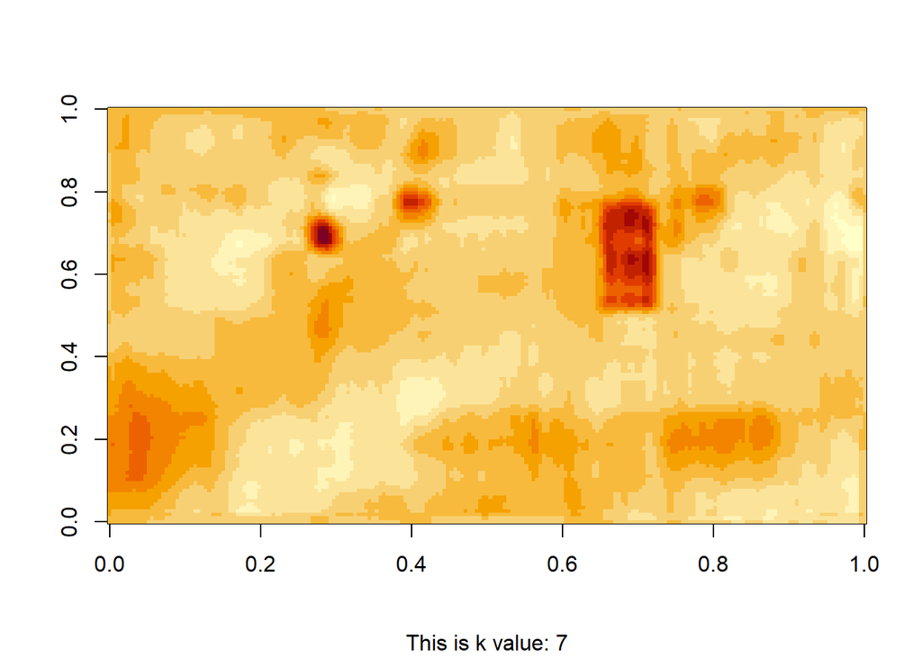

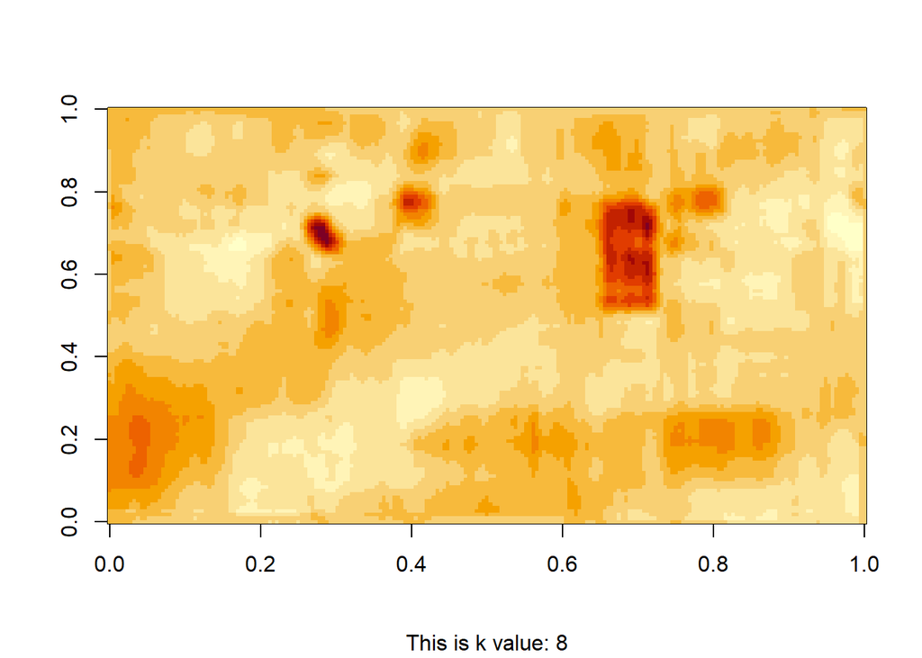

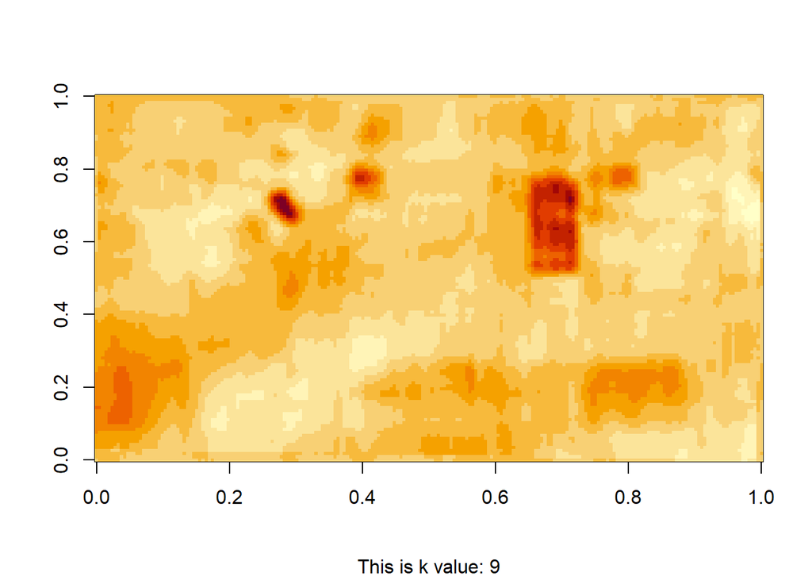

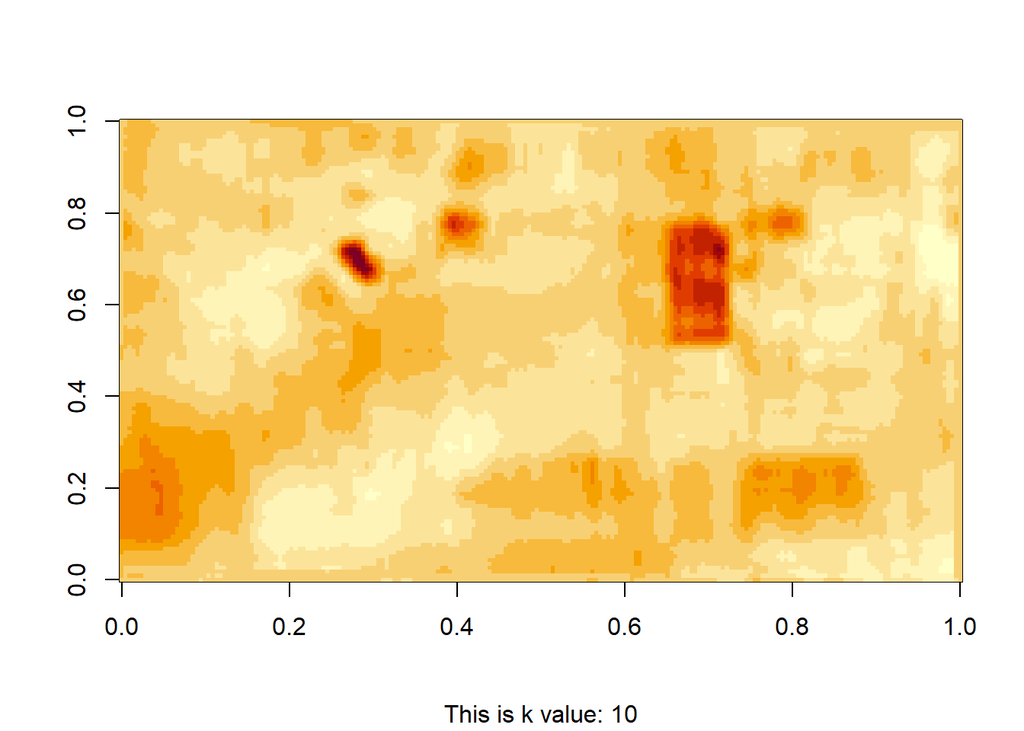

```r
first_10_img(img4)
```

2. A plot of the approximation error vs. 𝑘 for all possible values of 𝑘

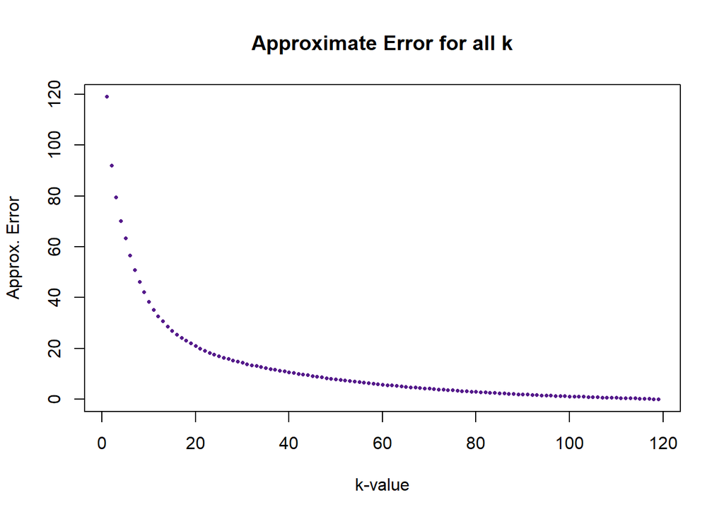

```r
k_error(img4)
```

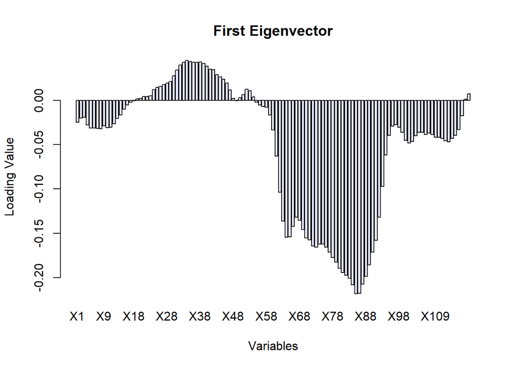

```r
# First eigenvector
eigenvector_plot(img4)
```

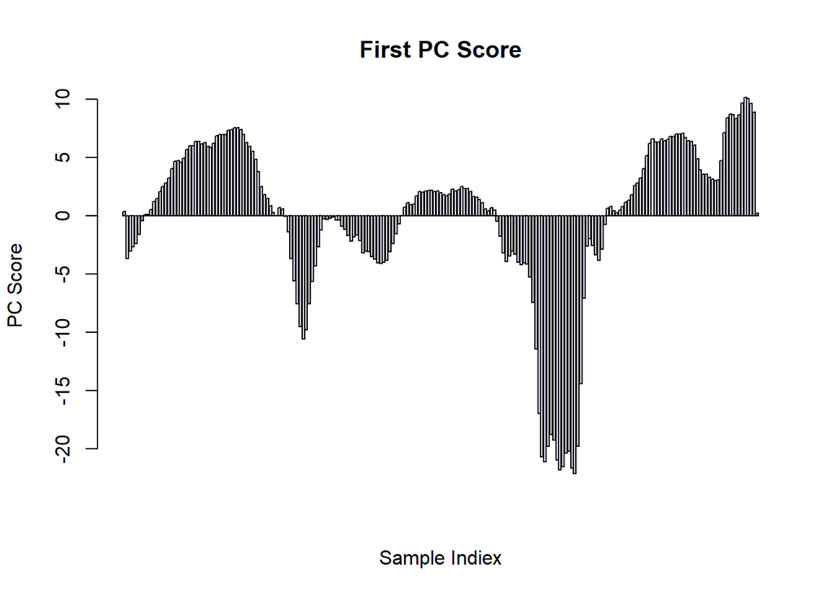

```r
# First PC score
pcscore_plot(img4)
```

4. Give your opinion for each image of at what value of 𝑘 you think the approximation to the image is sufficiently good.

This image is sufficiently clear at *k* = 4.

All the functions used to generate these plots can be found below.

**Code Below**

```r
# Input: image as a dataframe
# Output: Original image, plus 10
# PCA compression of that image
first_10_img <- function(img,
                         grayscale = FALSE){

  # 1) Original image ---------
  if (grayscale){
    # Grayscale the puppy image
    image(as.matrix(img), sub = "Original image", col = gray.colors(255))
  } else {
    image(as.matrix(img), sub = "Original image")
  }

  # 2) First 10 PCA approximations ----
  for (i in 1:10){

    # Grab function output
    pca_k = compress_image(img, i)

    # Create compressed image
    #image(pca_k[[1]], sub = paste("This is k value:", i))
    if (grayscale){
      image(pca_k[[1]], sub = paste("This is k value:", i), col = gray.colors(255))
    } else {
      image(pca_k[[1]], sub = paste("This is k value:", i))
    }

  }
}

# Input: image as a dataframe
# Output: Made error
k_error <- function(img){

  # Calculate highest number of dimensions p
  p = dim(img)[2]

  # Set up vector of k errors
  k_errors = numeric(p)

  # Loop through to find each error
  for (i in 1:p){
    pca_k= compress_image(img, i)

    # Add erroro value to vector
    k_errors[i] = pca_k[[2]]
  }

  # Make plot
  plot(1:p, k_errors,
       main = "Approximate Error for all k",
       xlab = "k-value",
       ylab = "Approx. Error",
       pch = 16,
       cex = 0.5, # make points smaller
       col = "purple4")

}

# Input: image as dataframe
# Output: Plot of first eigenvector
eigenvector_plot <- function(img){

  # Grab first eigenvector --------
  first_eigen <- prcomp(img,
                        center = FALSE,
                        scale. = FALSE
                        )$rotation[, 1]

  # Make plot
  barplot(first_eigen,
          main = "First Eigenvector",
          ylab = "Loading Value",
          xlab = "Variables",
          col = 'lavender')

}

# Input: image as dataframe
# Output: Plot of first PC score
pcscore_plot <- function(img){

  # Grab first PC score -----------
  first_pcscore = prcomp(img)$x[,1]

  # Make plot
  barplot(first_pcscore,
          col = "lavender",
          main = "First PC Score",
          ylab = "PC Score",
          xlab = "Sample Indiex",)

}
```